# Analysis of Sequential Data PART 1

## I. DATA

> From the library Mcomp, one of the monthly time series from the M3 forecasting competition is chosen to be analyzed in this Project. The series number is M34 and the name of the time series is N1435.  
> It has 51 observations(historical data) from January 1990 to March 1994 and the number of required forecasts(future data) is 18 which will be from April 1994 to September 1995.

```r
library(Mcomp)
monthly_ts_list <- subset(M3,"monthly")
fc <- monthly_ts_list[[34]]
```

## II. EXPLORATORY ANALYSIS

> *a. Plot the time series. What do you note by visual inspection?*  
> Figure below shows the monthly number of shipments of training data.  
> This time plot has a long term decreasing trend. There is no cyclic pattern or seasonality can be detected from this data.

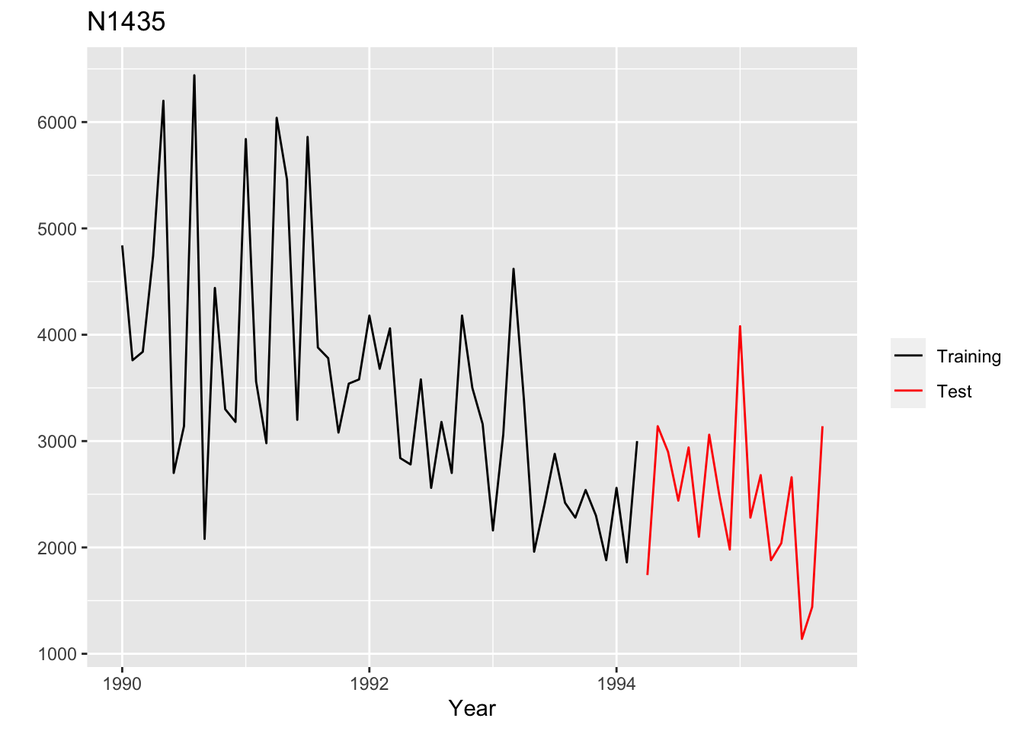

> *b. Corroborate your analysis by checking the seasonal plots and the autocorrelogram.*  
> Since there was no seasonality observed from the data, there is no such an information can be detected from seasonal plot due to monthly period.

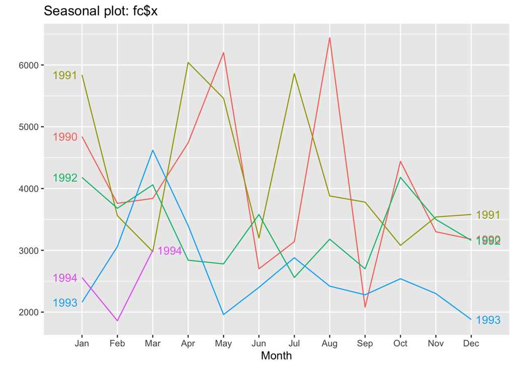

> The same goes for subseries plot as well. One can detect that, almost all the subseries plots showing decreasing trend.

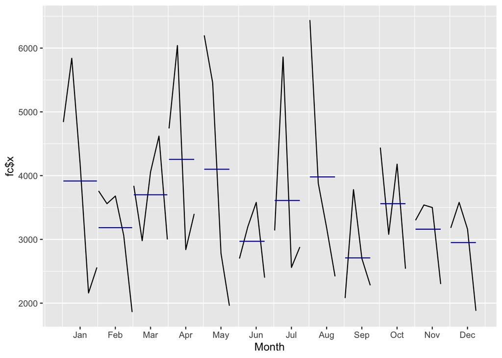

> The graph below (Polar seasonal plot) clearly shows how the variation is.

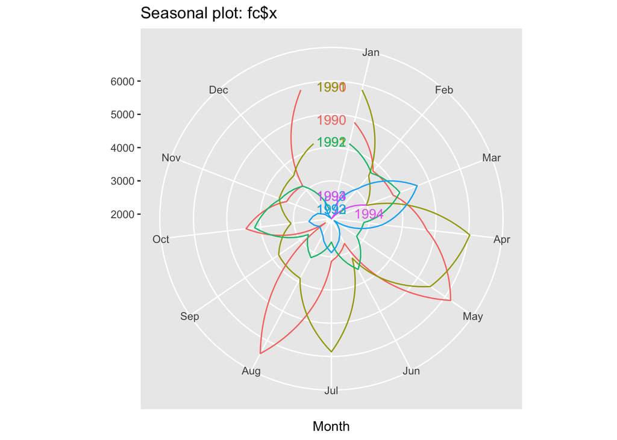

> The autocorrelation function (ACF) is plotted by calculating and graphing the residuals.  
> The autocorrelogram shows the residuals lie down inside of the blue borders which represents the residuals are actually white noise, other than the outlier, having no such a correlation.

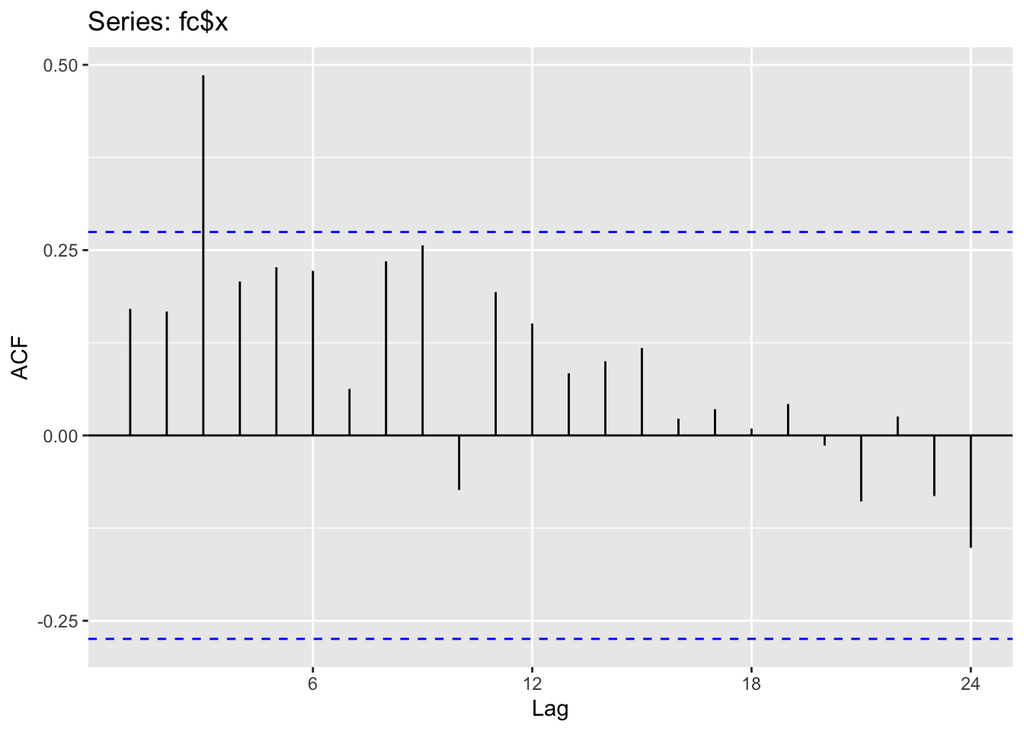

## III. INDICATORS

> *Select two meaningful indicators for the forecast on this time series. Point out what could be a good objective on both indicators.*  
> **MAE(Mean Absolute Error)** avoids the problem of positive and negative forecast errors. As the name suggests, the mean absolute error is the average of the absolute values of the forecast errors.  
> **MSE(Mean Squared Error)** also avoids the challenge of positive and negative forecast errors offsetting each other. It is obtained by: · First, calculating the square of the forecast error · Then, taking the average of the squared forecast error  
> The size of MAE or RMSE depends upon the scale of the data. As a result, it is difficult to make comparisons for a different time interval.  
> In such cases, use  
> **MAPE (mean absolute percentage error)**. Steps for calculating MAPE:  
> a) by dividing the absolute forecast error by the actual value, b) calculating the average of individual absolute percentage error. If the data series has few values which are zero or very small (close to zero), MAPE would not be a correct metric to compare the model. Even though forecast might be reasonably good, MAPE could be very high due to those zero values.

> The MAE may be preferred because it is simple to explain. If all data are positive and much greater than zero, the MAPE may be preferred for reasons of simplicity as well.  
> Lower the values of these measures, the more accurate prediction model is.

> As an example, the examples below shows the accuracy metrics of the prediction of Naive and Exponential Smoothing models.

```r
fcAccNaive <- naive(fc$x,h=18)
accuracy(fcAccNaive, fc$xx)
```

```
##                     ME      RMSE       MAE        MPE     MAPE      MASE
## Training set  -36.8000 1488.5752 1107.2000  -9.049678 32.75695 0.9827219
## Test set     -548.8889  883.5031  706.6667 -34.070605 38.22045 0.6272189
##                    ACF1 Theil's U
## Training set -0.5002486        NA
## Test set     -0.1488686 0.8928568
```

```r
fcAccSES <- ses(fc$x,h=18)
accuracy(fcAccSES, fc$xx)
```

[output not shown]

> We can compare two models with the indicator MAPE.  
> Second model has lower MAPE value on test set, we can say that it is better model.

## IV. SIMPLE MODEL

> *a. Discuss which simple model (mean, random walk, random walk with drift, seasonal naive, etc) is the most appropriate for this the time series.*  
> In this section, some simple models are used for forecasting.  
> * **Mean(average)** method, the forecasts of all future values are estimated as equal to the average.  
> * **Naive(random walk)** method, simply set all forecasts to be the value of the last observation.  
> * **Drift(random walk with drift)** method, a variation on the naïve method is to allow the forecasts to increase or decrease over time, where the amount of change over time (called the drift) is set to be the average change seen in the historical data.  
> * **Seasonal Naive** method, set each forecast to be equal to the last observed value from the same season of the year.

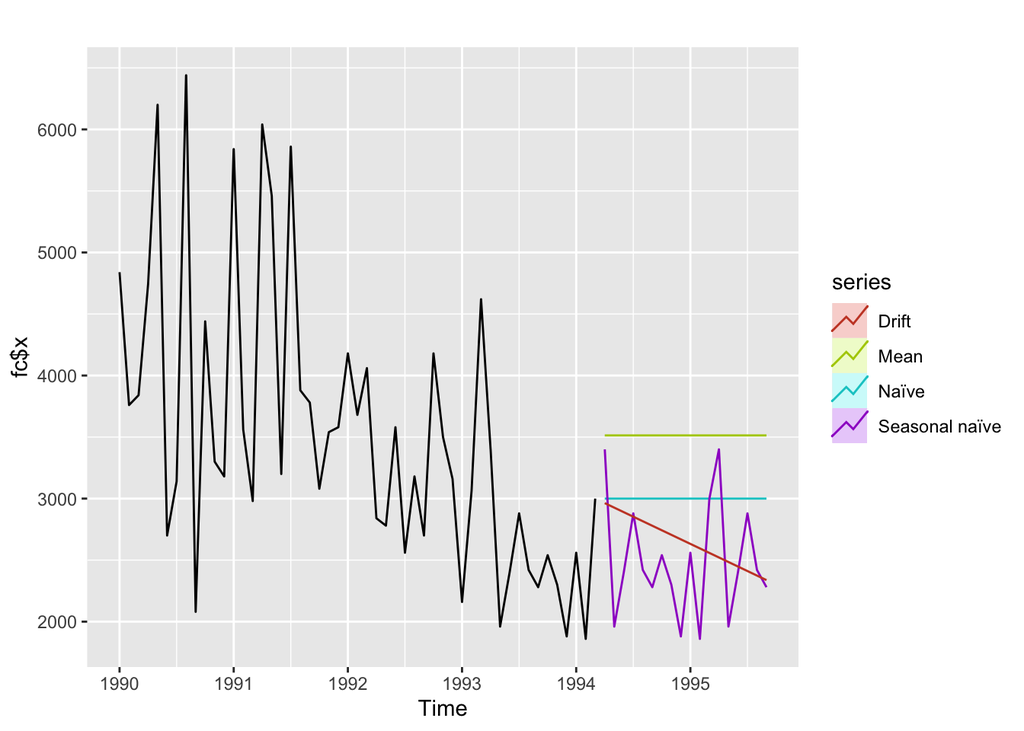

> *b. Fit the selected model, check its residuals and the performance on the test set and compare it with your goal.*

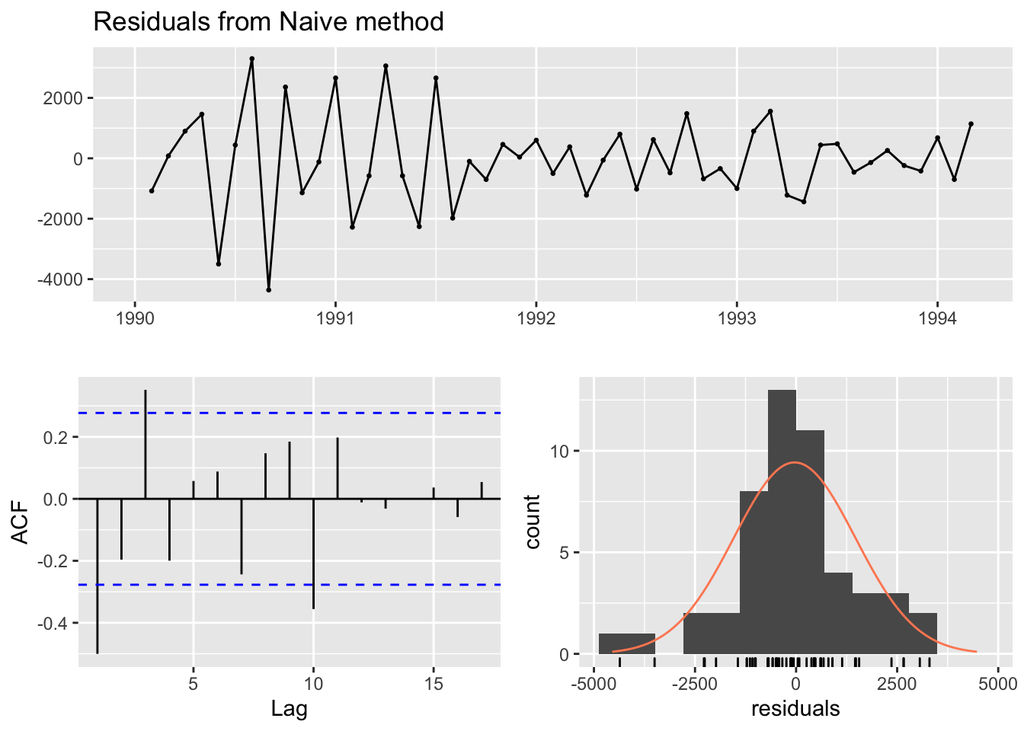

```
##
##  Ljung-Box test
##
## data:  Residuals from Naive method
## Q* = 40.421, df = 10, p-value = 1.429e-05
##
## Model df: 0.   Total lags used: 10
```

```
##                     ME      RMSE       MAE        MPE     MAPE      MASE
## Training set  -36.8000 1488.5752 1107.2000  -9.049678 32.75695 0.9827219
## Test set     -548.8889  883.5031  706.6667 -34.070605 38.22045 0.6272189
##                    ACF1 Theil's U
## Training set -0.5002486        NA
## Test set     -0.1488686 0.8928568
```

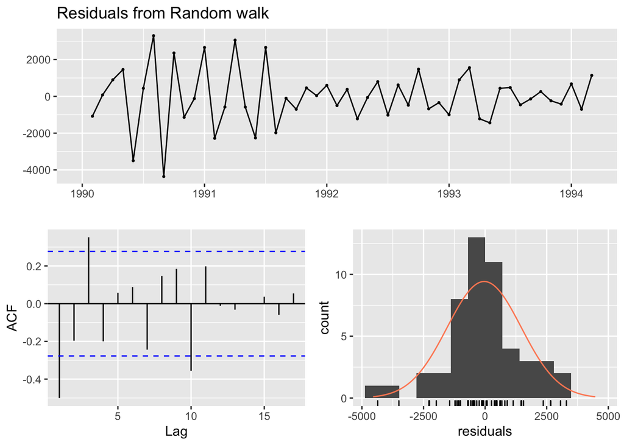

```
##
##  Ljung-Box test
##
## data:  Residuals from Random walk
## Q* = 40.421, df = 10, p-value = 1.429e-05
##
## Model df: 0.   Total lags used: 10
```

```
##                         ME      RMSE       MAE       MPE     MAPE      MASE
## Training set -1.409517e-13 1488.1202 1104.2560  -7.88620 32.49791 0.9801089
## Test set     -1.992889e+02  699.7395  560.3556 -17.46048 28.05043 0.4973570
##                    ACF1 Theil's U
## Training set -0.5002486        NA
## Test set     -0.2978277 0.6855025
```

## V. Exponential Smoothing

> *a. Hypothesize which type of exponential smoothing model could be appropriate. Fit the model, check its residuals and the performance on the test set.*  
> In this section, types of exponential smoothing models such as Simple Exponential Smoothing, Holt’s Linear Model and Damped Trend Model are compared. The time series have a trend but it is not linear, long term decreasing trend.

```r
fcSES <- ses(fc$x, h=18)
fcHolt <- holt(fc$x, h=18)
fcDamped <- holt(fc$x, damped=TRUE, h=18)
```

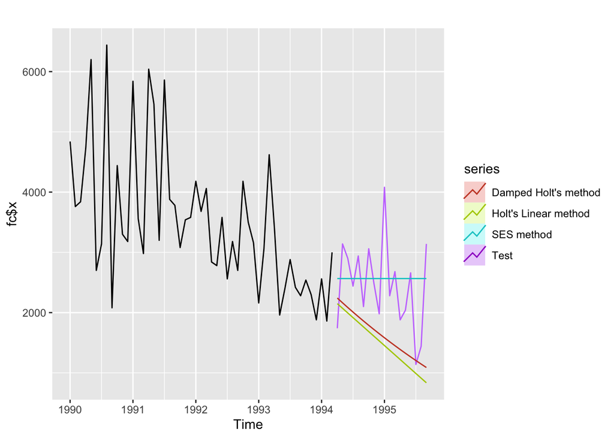

> The forecasting results shows SES method has more accurate values than the other methods.

> *b. Compare with the results of the simple model.*  
> Simple Exponential Model:

```
## Simple exponential smoothing
##
## Call:
##  ses(y = fc$x, h = 18)
##
##   Smoothing parameters:
##     alpha = 0.1485
##
##   Initial states:
##     l = 4237.9017
##
##   sigma:  1056.613
##
##      AIC     AICc      BIC
## 914.6909 915.2015 920.4864
```

```
##                     ME      RMSE      MAE        MPE     MAPE      MASE
## Training set -220.8569 1035.6881 840.4536 -14.244511 25.79516 0.7459647
## Test set      120.7376  662.1945 538.0000  -1.182822 20.36011 0.4775148
##                    ACF1 Theil's U
## Training set -0.2441677        NA
## Test set     -0.4083836 0.6264285
```

> Holt’s Linear model:

```
## Holt's method
##
## Call:
##  holt(y = fc$x, h = 18)
##
##   Smoothing parameters:
##     alpha = 0.0091
##     beta  = 0.0091
##
##   Initial states:
##     l = 4599.5055
##     b = -11.4438
##
##   sigma:  1005.357
##
##      AIC     AICc      BIC
## 911.4935 912.8269 921.1527
```

```
##                     ME      RMSE      MAE       MPE     MAPE      MASE
## Training set -141.1447  965.1265 752.4873 -10.69854 22.65127 0.6678882
## Test set      885.0300 1161.0804 966.7690  28.39110 33.08874 0.8580790
##                    ACF1 Theil's U
## Training set -0.2224976        NA
## Test set     -0.2592739  1.166833
```

> Damped Holt’s model:

```
## Damped Holt's method
##
## Call:
##  holt(y = fc$x, h = 18, damped = TRUE)
##
##   Smoothing parameters:
##     alpha = 0.0123
##     beta  = 0.0123
##     phi   = 0.98
##
##   Initial states:
##     l = 4573.4787
##     b = -30.794
##
##   sigma:  1037.029
##
##      AIC     AICc      BIC
## 915.5605 917.4696 927.1515
```

```
##                     ME      RMSE      MAE       MPE     MAPE      MASE
## Training set -153.2798  984.8836 774.9892 -11.71119 23.47552 0.6878602
## Test set      782.7251 1080.2264 883.1013  24.38008 30.14883 0.7838178
##                    ACF1 Theil's U
## Training set -0.1829691        NA
## Test set     -0.2701754  1.087952
```

## VI. ETS and AUTO-ARIMA

> *a. Fit, check the residual and the test set performance of both ets and auto.arima.*  
> The function ETS shows that the time series has multiplicative error component, additive trend with no seasonality (M,A,N).

```r
fitETS <- ets(fc$x)
summary(fitETS)
```

```
## ETS(M,A,N)
##
## Call:
##  ets(y = fc$x)
##
##   Smoothing parameters:
##     alpha = 0.0136
##     beta  = 0.0136
##
##   Initial states:
##     l = 4552.9648
##     b = 16.5412
##
##   sigma:  0.2613
##
##      AIC     AICc      BIC
## 902.6216 903.9549 912.2807
##
## Training set error measures:
##                     ME     RMSE      MAE       MPE     MAPE      MASE
## Training set -112.1869 973.5207 755.4631 -9.107527 22.43136 0.6705294
##                    ACF1
## Training set -0.2039882
```

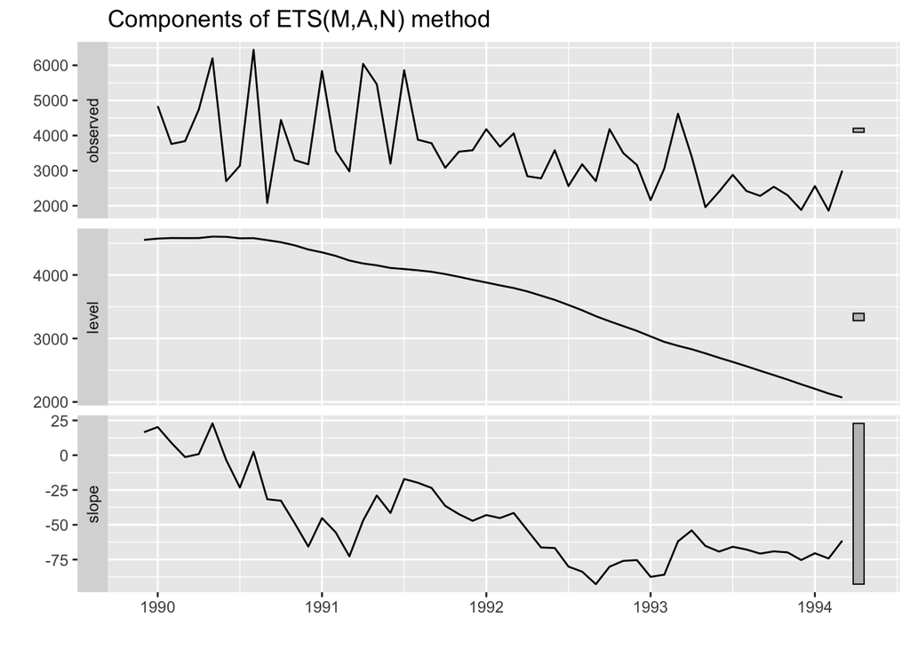

```r
autoplot(fitETS)
```

> AIC value of ETS(M,A,N) model is 902.62.

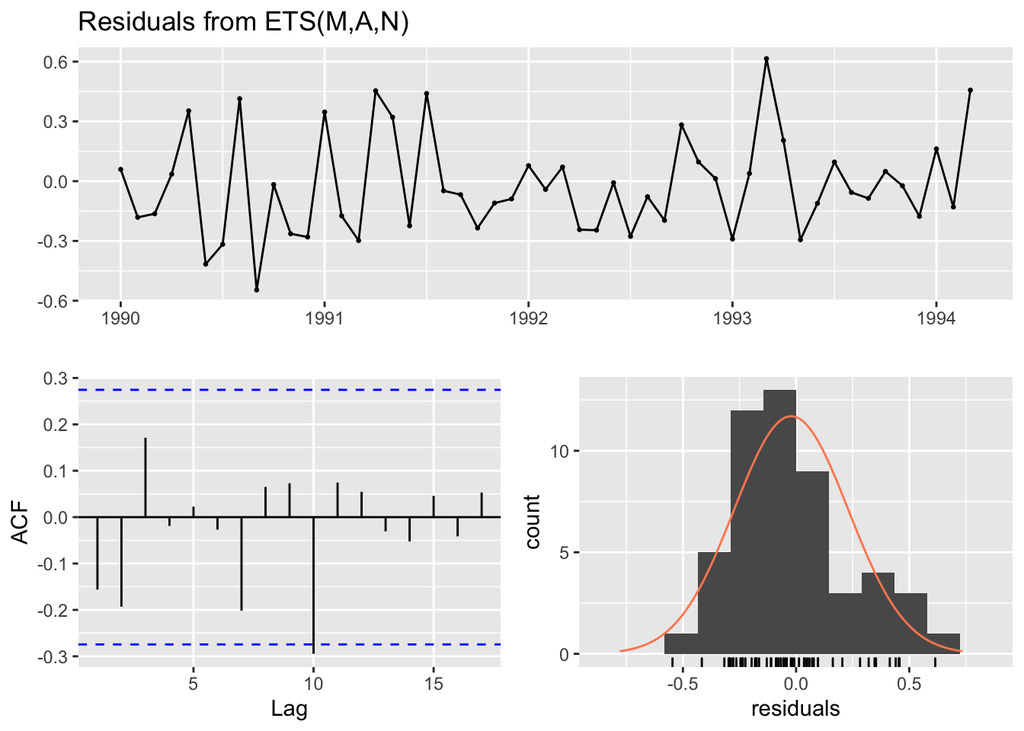

```
##
##  Ljung-Box test
##
## data:  Residuals from ETS(M,A,N)
## Q* = 13.954, df = 6, p-value = 0.03015
##
## Model df: 4.   Total lags used: 10
```

```r
checkresiduals(fitETS)
```

> Exponential smoothing and ARIMA models are the two most widely used approaches to time series forecasting. While exponential smoothing models are based on a description of the trend and seasonality in the data, ARIMA models aim to describe the autocorrelations in the data. Before we introduce ARIMA models, we must check the concept of stationarity.

```r
nsdiffs(fc$x)
```

```
## [1] 0
```

```r
ndiffs(fc$x)
```

```
## [1] 1
```

```r
ndiffs(diff(fc$x))
```

```
## [1] 0
```

> Since our model has no seasonality, nsdiffs returns 0 (no seasonal differencing needed).  
> To make the time series stationary, we need to calculate differencing once(ndiffs returns 1 for time series, further differencing not needed).

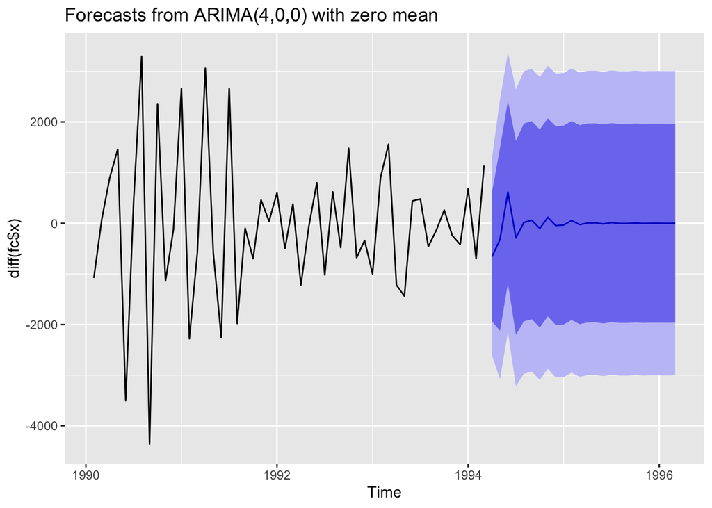

```r
fitArima <- auto.arima(diff(fc$x) )
autoplot(forecast(fitArima))
```

> The function auto.arima() returns the time series as ARIMA(4,0,0) with zero mean, which means, p(order of autoregressive part) is 4, d(differencing) equals 0, q(order of the moving average part) is 0.

```r
fitArima
```

```
## Series: diff(fc$x)
## ARIMA(4,0,0) with zero mean
##
## Coefficients:
##           ar1      ar2      ar3      ar4
##       -1.0023  -0.9979  -0.4902  -0.2768
## s.e.   0.1367   0.1864   0.1875   0.1388
##
## sigma^2 estimated as 989678:  log likelihood=-414.82
## AIC=839.64   AICc=841   BIC=849.2
```

> AIC value of ARIMA(4,0,0) model is 839.64.

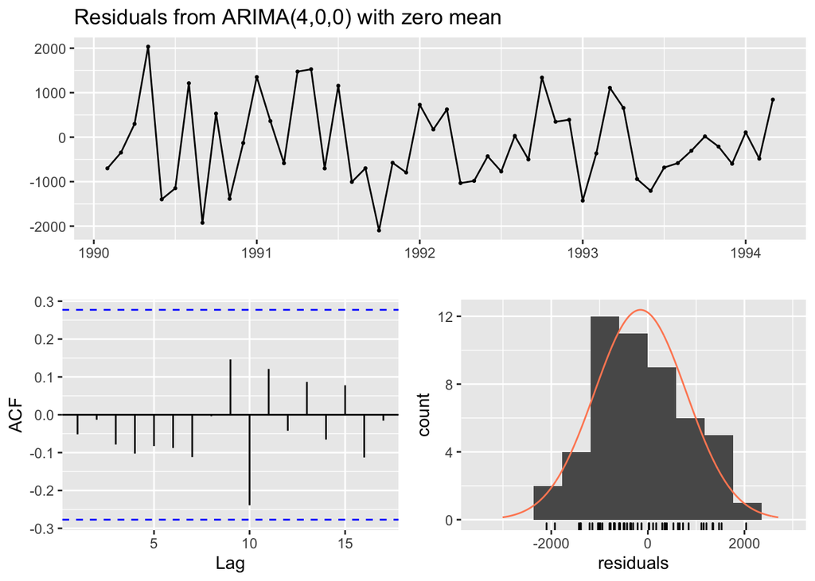

```
##
##  Ljung-Box test
##
## data:  Residuals from ARIMA(4,0,0) with zero mean
## Q* = 7.7601, df = 6, p-value = 0.2562
##
## Model df: 4.   Total lags used: 10
```

```r
checkresiduals(fitArima)
```

> *b. Compare their results to the results of the previous models and discuss any important characteristic that such models might contain.*  
> If we compare ETS(M,A,N) and ARIMA(4,0,0) models on the same time series we can say that ARIMA model has better performance since the AIC value is lower than the ETS model.

## VII. CONCLUSIONS

> *a. State the most important conclusions of your analysis.*  
> The chosen time series showing decreasing trend with no seasonality or no cyclic pattern. Residuals are showing almost White Noise behavior.  
> Comparing the simple, exponential smoothing, ETS and ARIMA models, the most accurate model was ARIMA(4,0,0) with one time differenced time series